# MV_Coursework_rmd_2060361

HELEN SOREMEKUN

2024-03-19

```r
#install.packages("rmarkdown")
```

## Introduction

This is an analysis of United Nations dataset about the GDP per capita, the life expectancy, and the population of 141 different countries from 1952 to 2007 at a five-year interval.

This dataset consists of multiple variables that are suitable for key multivariate analysis, dimension reduction, dimension scaling, correlation and regression analysis, discriminant analysis and clustering. The aim of this multivariate analysis is to produce useful insights from three measurements, the GDP per capita, the life expectancy and the population size from the data set.

#loading the UN dataset.

```r
UN <- read.csv('UN.csv')
UN
```

```
##     continent                  country gdpPercap_1952 gdpPercap_1957
## 1      Africa                  Algeria      2449.0082      3013.9760
## 2      Africa                   Angola      3520.6103      3827.9405
## 3      Africa                    Benin      1062.7522       959.6011
## 4      Africa                 Botswana       851.2411       918.2325
## 5      Africa             Burkina Faso       543.2552       617.1835
## 6      Africa                  Burundi       339.2965       379.5646
## 7      Africa                 Cameroon      1172.6677      1313.0481
## 8      Africa Central African Republic      1071.3107      1190.8443
## 9      Africa                     Chad      1178.6659      1308.4956
## 10     Africa                  Comoros      1102.9909      1211.1485
## 11     Africa          Congo Dem. Rep.       780.5423       905.8602
## 12     Africa               Congo Rep.      2125.6214      2315.0566
## 13     Africa            Cote d'Ivoire      1388.5947      1500.8959
## 14     Africa                 Djibouti      2669.5295      2864.9691
```

[output cut: 979 more lines]

```r
#UN.head()
```

##.

##Exploratory Data Analysis The exploratory data analysis covers loading the dataset into the R studio, data cleaning and visualisation with R packages. The data cleaning process consists of the summary statistics, checks for missing values in rows, duplicate rows, and checks for outliers in the GDP Per Capita, Life Expectancy in the data set.

#Check for missing values

```r
missing_values <- colSums(is.na(UN))
if (any(missing_values > 0)) {
  print("Columns with missing values:")
  print(missing_values[missing_values > 0])
} else {
  print("No missing values found.")
}
```

```
## [1] "No missing values found."
```

```r
# Check for duplicate rows
duplicate_rows <- UN[duplicated(UN), ]
if (nrow(duplicate_rows) > 0) {
  print("Duplicate rows found:")
  print(duplicate_rows)
} else {
  print("No duplicate rows found.")
}
```

```
## [1] "No duplicate rows found."
```

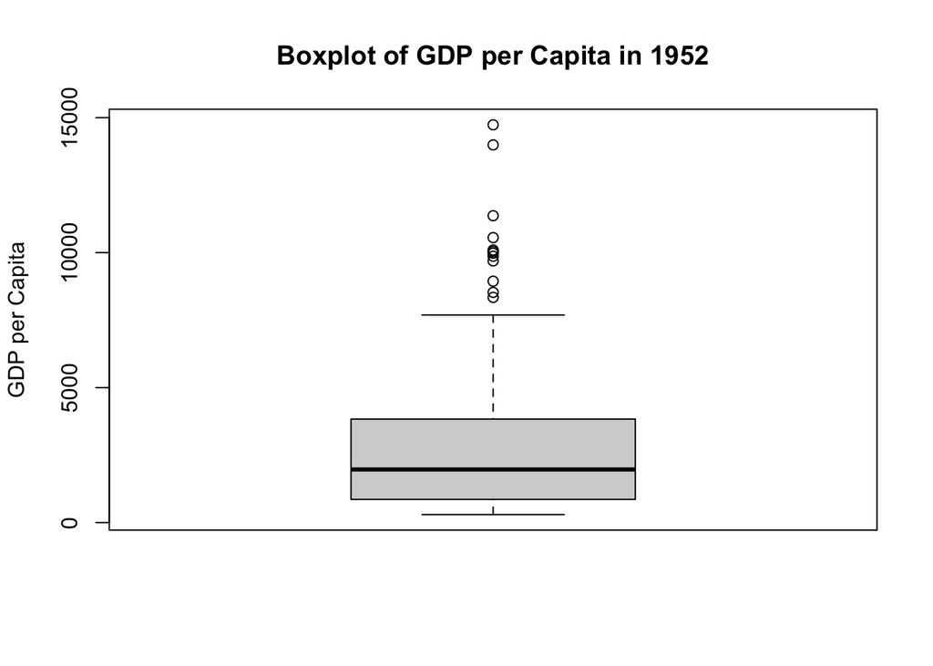

```r
#Boxplot for numerical columns to visualize outliers
boxplot(UN$gdpPercap_1952, main="Boxplot of GDP per Capita in 1952", ylab="GDP per Capita")
```

#Figure 1. Boxplot of GDP per Capita in 1952.

```r
#Outlier detection using Z-score method for GDP per Capita in 1952
z_scores <- (UN$gdpPercap_1952 - mean(UN$gdpPercap_1952)) / sd(UN$gdpPercap_1952)
outliers <- UN[abs(z_scores) > 3, ]
if (nrow(outliers) > 0) {
  print("Outliers found in GDP per Capita in 1952:")
  print(outliers)
} else {
  print("No outliers found in GDP per Capita in 1952.")
}
```

```
## [1] "Outliers found in GDP per Capita in 1952:"
##     continent       country gdpPercap_1952 gdpPercap_1957 gdpPercap_1962
## 75   Americas United States       13990.48       14847.13       16173.15
## 137    Europe   Switzerland       14734.23       17909.49       20431.09
##     gdpPercap_1967 gdpPercap_1972 gdpPercap_1977 gdpPercap_1982 gdpPercap_1987
## 75        19530.37       21806.04       24072.63       25009.56       29884.35
## 137       22966.14       27195.11       26982.29       28397.72       30281.70
##     gdpPercap_1992 gdpPercap_1997 gdpPercap_2002 gdpPercap_2007 lifeExp_1952
## 75        32003.93       35767.43       39097.10       42951.65        68.44
## 137       31871.53       32135.32       34480.96       37506.42        69.62
##     lifeExp_1957 lifeExp_1962 lifeExp_1967 lifeExp_1972 lifeExp_1977
## 75         69.49        70.21        70.76        71.34        73.38
## 137        70.56        71.32        72.77        73.78        75.39
##     lifeExp_1982 lifeExp_1987 lifeExp_1992 lifeExp_1997 lifeExp_2002
## 75         74.65        75.02        76.09        76.81        77.31
## 137        76.21        77.41        78.03        79.37        80.62
##     lifeExp_2007  pop_1952  pop_1957  pop_1962  pop_1967  pop_1972  pop_1977
## 75        78.242 157553000 171984000 186538000 198712000 209896000 220239000
## 137       81.701   4815000   5126000   5666000   6063000   6401400   6316424
##      pop_1982  pop_1987  pop_1992  pop_1997  pop_2002  pop_2007
## 75  232187835 242803533 256894189 272911760 287675526 301139947
## 137   6468126   6649942   6995447   7193761   7361757   7554661
```

#Summary Statistics of the whole UN data

```r
summary(UN)
```

```
##   continent           country          gdpPercap_1952    gdpPercap_1957
##  Length:141         Length:141         Min.   :  298.8   Min.   :  336.0
##  Class :character   Class :character   1st Qu.:  859.8   1st Qu.:  925.9
##  Mode  :character   Mode  :character   Median : 1968.0   Median : 2127.7
##                                        Mean   : 2983.0   Mean   : 3524.8
##                                        3rd Qu.: 3834.0   3rd Qu.: 4756.5
##                                        Max.   :14734.2   Max.   :17909.5
##  gdpPercap_1962    gdpPercap_1967  gdpPercap_1972  gdpPercap_1977
##  Min.   :  355.2   Min.   :  349   Min.   :  357   Min.   :  371
##  1st Qu.: 1056.4   1st Qu.: 1136   1st Qu.: 1255   1st Qu.: 1349
##  Median : 2322.9   Median : 2678   Median : 3313   Median : 3781
##  Mean   : 4082.3   Mean   : 4949   Mean   : 6043   Mean   : 6945
##  3rd Qu.: 5693.8   3rd Qu.: 6960   3rd Qu.: 9443   3rd Qu.:11186
##  Max.   :20431.1   Max.   :22966   Max.   :27195   Max.   :34168
##  gdpPercap_1982  gdpPercap_1987  gdpPercap_1992  gdpPercap_1997
##  Min.   :  424   Min.   :  385   Min.   :  347   Min.   :  312.2
##  1st Qu.: 1348   1st Qu.: 1316   1st Qu.: 1247   1st Qu.: 1360.5
##  Median : 4191   Median : 4246   Median : 4333   Median : 4766.4
##  Mean   : 7350   Mean   : 7758   Mean   : 7969   Mean   : 8868.8
##  3rd Qu.:11754   3rd Qu.:11864   3rd Qu.:10536   3rd Qu.:11712.8
##  Max.   :33693   Max.   :31541   Max.   :33966   Max.   :41283.2
##  gdpPercap_2002    gdpPercap_2007     lifeExp_1952    lifeExp_1957
##  Min.   :  241.2   Min.   :  277.6   Min.   :28.80   Min.   :30.33
##  1st Qu.: 1372.9   1st Qu.: 1598.4   1st Qu.:39.03   1st Qu.:41.21
##  Median : 5288.0   Median : 6025.4   Median :45.01   Median :48.28
##  Mean   : 9739.2   Mean   :11427.4   Mean   :49.01   Mean   :51.46
##  3rd Qu.:12521.7   3rd Qu.:18008.5   3rd Qu.:59.82   3rd Qu.:63.18
##  Max.   :44684.0   Max.   :49357.2   Max.   :72.67   Max.   :73.47
##   lifeExp_1962    lifeExp_1967    lifeExp_1972    lifeExp_1977
##  Min.   :32.00   Min.   :34.02   Min.   :35.40   Min.   :31.22
##  1st Qu.:43.43   1st Qu.:45.96   1st Qu.:48.44   1st Qu.:50.35
##  Median :50.30   Median :53.66   Median :56.53   Median :59.51
##  Mean   :53.56   Mean   :55.61   Mean   :57.58   Mean   :59.50
##  3rd Qu.:65.25   3rd Qu.:67.50   3rd Qu.:69.26   3rd Qu.:70.41
##  Max.   :73.68   Max.   :74.16   Max.   :74.72   Max.   :76.11
##   lifeExp_1982    lifeExp_1987    lifeExp_1992    lifeExp_1997
##  Min.   :38.45   Min.   :39.91   Min.   :23.60   Min.   :36.09
##  1st Qu.:52.93   1st Qu.:54.93   1st Qu.:56.02   1st Qu.:55.56
##  Median :62.16   Median :65.80   Median :67.66   Median :69.39
##  Mean   :61.46   Mean   :63.13   Mean   :64.08   Mean   :64.94
```

[output cut: 22 more lines]

```
##  Max.   :943455000   Max.   :1.000e+09   Max.   :1.084e+09
##     pop_1992            pop_1997            pop_2002
##  Min.   :1.259e+05   Min.   :1.456e+05   Min.   :1.704e+05
##  1st Qu.:3.668e+06   1st Qu.:3.802e+06   1st Qu.:4.198e+06
##  Median :8.719e+06   Median :9.804e+06   Median :1.043e+07
##  Mean   :3.624e+07   Mean   :3.910e+07   Mean   :4.174e+07
##  3rd Qu.:2.280e+07   3rd Qu.:2.475e+07   3rd Qu.:2.677e+07
##  Max.   :1.165e+09   Max.   :1.230e+09   Max.   :1.280e+09
##     pop_2007
##  Min.   :1.996e+05
##  1st Qu.:4.552e+06
##  Median :1.064e+07
##  Mean   :4.432e+07
##  3rd Qu.:3.189e+07
##  Max.   :1.319e+09
```

# Interpretation of results:Initial Exploratory Data Analysis.

The data set appears to have been cleaned, no missing values or duplicate rows were found. There were a few outliers in GDPs per Capita for some countries, over the years. The average GDPs per Capita appears to increase rapidly over the years Oceania and Europe with Oceania having the highest economic growth over the years. Africa has the lowest rate of increase over the year with some dips around 1990 and then a rise towards 2007.

#Installing and loading necessary packages

```r
#installing packages
#install.packages("dplyr")
#install.packages("tidyr")
#install.packages("ggplot2")
```

```r
#install.packages("corrplot")
library(corrplot)
library(ggplot2)
library(dplyr)
library(tidyr)
```

```r
#update.packages()
```

#data visualization In this exploration, the relationship between the average life expectancy and GDP per capita over time for each continent was obtained using line plots. The comparison between the correlation between GDPs per Capita and Life Expectancy in 1952 and 2007 was obtained using scatterplots. The economic growth, population, and life expectancy of each continent over time was visualized with the line plot.

#how the average life expectancy and GDP per capita for each continent has changed through time.

```r
# Reshaping the GDP per capita data to long format
gdp_long <- UN %>%
  gather(key = "year_gdp", value = "gdpPercap", starts_with("gdpPercap_")) %>%
  mutate(year = as.integer(substr(year_gdp, 11, 14))) %>% # Extracting the year from column names
  select(-year_gdp)
```

```r
# Reshaping the life expectancy data to long format
lifeExp_long <- UN %>%
  gather(key = "year_lifeExp", value = "lifeExp", starts_with("lifeExp_")) %>%
  mutate(year = as.integer(substr(year_lifeExp, 9, 12))) %>% # Extracting the year from column names
  select(-year_lifeExp)
```

```r
# Joining the reshaped GDP and life expectancy data by their common columns
df_long <- left_join(gdp_long, lifeExp_long, by = c("continent", "country", "year"))

# obtaining the mean GDP per capita and life expectancy for each continent and year
df_avg <- df_long %>%
  group_by(continent, year) %>%
  summarise(avg_gdpPercap = mean(gdpPercap, na.rm = TRUE),
            avg_lifeExp = mean(lifeExp, na.rm = TRUE))
```

#lets explore the trend life expectancy over years in continent.

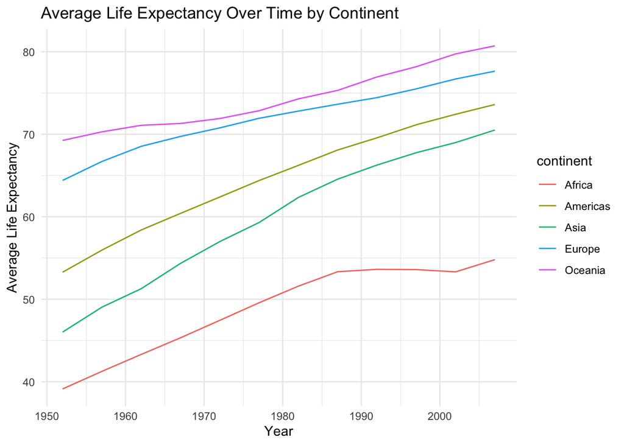

```r
# Plotting the average life expectancy over time for each continent
ggplot(df_avg, aes(x = year, y = avg_lifeExp, group = continent, color = continent)) +
  geom_line() +
  theme_minimal() +
  labs(title = "Average Life Expectancy Over Time by Continent",
       x = "Year",
       y = "Average Life Expectancy")
```

#Figure 2. Average Life Expectancy Over Time by Continent.

#lets check economic growth countries/continents over the years.

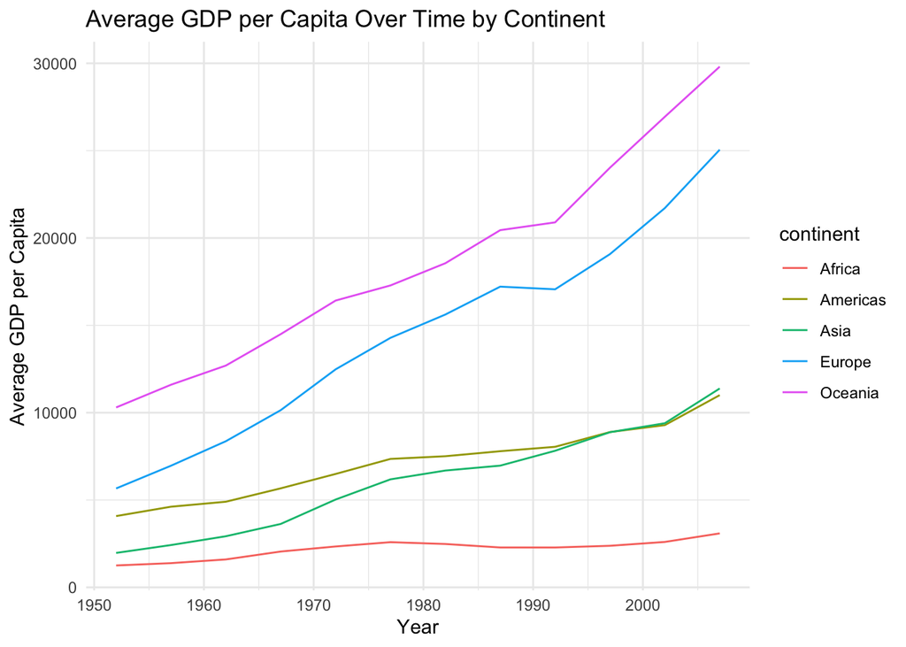

```r
# Plotting the average GDP per capita over time for each continent
ggplot(df_avg, aes(x = year, y = avg_gdpPercap, group = continent, color = continent)) +
  geom_line() +
  theme_minimal() +
  labs(title = "Average GDP per Capita Over Time by Continent",
       x = "Year",
       y = "Average GDP per Capita")
```

#Figure 3. Average GDP per Capita Over Time by Continent.

#lets explore how population per continent grew over years considering each continent

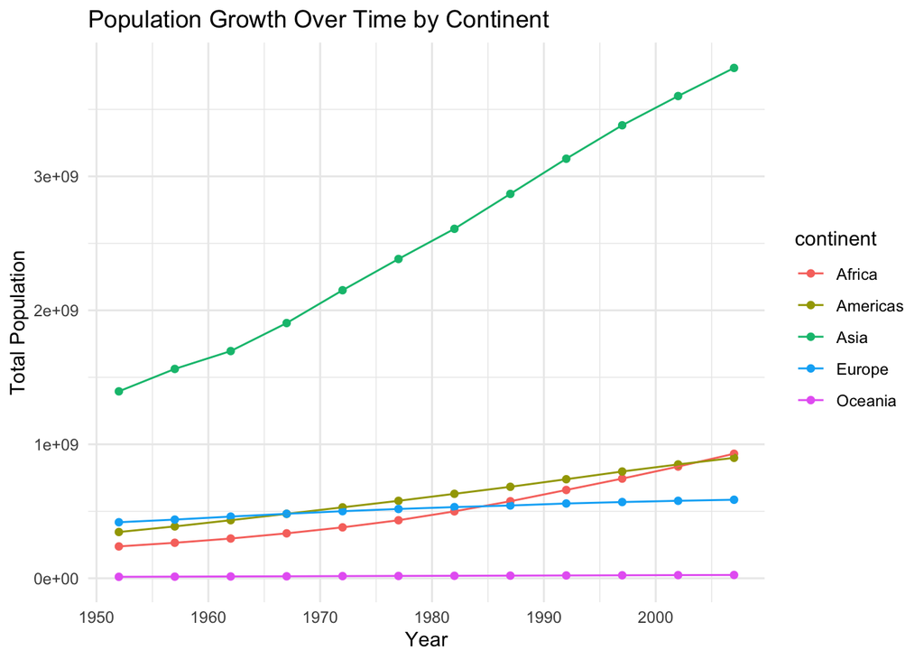

```r
UN %>%
  pivot_longer(
    cols = starts_with("pop_"),
    names_to = "year",
    values_to = "population",
    names_prefix = "pop_"
  ) %>%
  mutate(year = as.numeric(year)) %>%
  group_by(continent, year) %>%
  summarise(total_population = sum(population, na.rm = TRUE), .groups = "drop") %>%
  ggplot(aes(x = year, y = total_population, color = continent)) +
    geom_point() +
    geom_line(aes(group = continent)) +   # Adding lines to connect points for each continent
    labs(x = "Year", y = "Total Population", title = "Population Growth Over Time by Continent") +
    theme_minimal()
```

#Figure 4. Population Growth Over Time by Continent.